# p8105_hw6_cn2604

Cary Ni

2022-11-19

# Problem 1

To obtain the distribution for $\hat{r}^2$, we’ll follow basically the same procedure we used for regression coefficients: draw bootstrap samples; the a model to each; extract the value I’m concerned with; and summarize. Here, we’ll use `modelr::bootstrap` to draw the samples and `broom::glance` to produce `r.squared` values.

```r
weather_df =
  rnoaa::meteo_pull_monitors(
    c("USW00094728"),
    var = c("PRCP", "TMIN", "TMAX"),
    date_min = "2017-01-01",
    date_max = "2017-12-31") %>%
  mutate(
    name = recode(id, USW00094728 = "CentralPark_NY"),
    tmin = tmin / 10,
    tmax = tmax / 10) %>%
  select(name, id, everything())
```

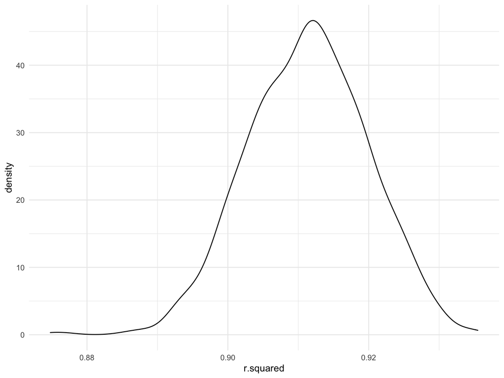

```r
weather_df %>%
  modelr::bootstrap(n = 1000) %>%
  mutate(
    models = map(strap, ~lm(tmax ~ tmin, data = .x) ),
    results = map(models, broom::glance)) %>%
  select(-strap, -models) %>%
  unnest(results) %>%
  ggplot(aes(x = r.squared)) + geom_density()
```

In this example, the r hat squared value is high, and the upper bound at 1 may be a cause for the generally skewed shape of the distribution. If we wanted to construct a confidence interval for $R^2$, we could take the 2.5% and 97.5% quantiles of the estimates across bootstrap samples. However, because the shape isn’t symmetric, using the mean +/- 1.96 times the standard error probably wouldn’t work well.

We can produce a distribution for $\log(\beta_0 * \beta1)$ using a similar approach, with a bit more wrangling before we make our plot.

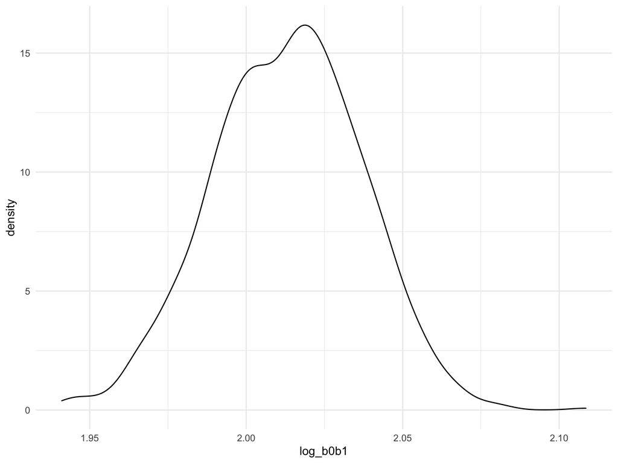

```r
weather_df %>%
  modelr::bootstrap(n = 1000) %>%
  mutate(
    models = map(strap, ~lm(tmax ~ tmin, data = .x) ),
    results = map(models, broom::tidy)) %>%
  select(-strap, -models) %>%
  unnest(results) %>%
  select(id = `.id`, term, estimate) %>%
  pivot_wider(
    names_from = term,
    values_from = estimate) %>%
  rename(beta0 = `(Intercept)`, beta1 = tmin) %>%
  mutate(log_b0b1 = log(beta0 * beta1)) %>%
  ggplot(aes(x = log_b0b1)) + geom_density()
```

The point of this is not to say you should always use the bootstrap – it’s possible to establish “large sample” distributions for strange parameters / values / summaries in a lot of cases, and those are great to have. But it is helpful to know that there’s a way to do inference even in tough cases.

# Problem 2

## Data cleaning

```r
homi_df = read_csv("./data/homicide-data.csv") %>%
  janitor::clean_names() %>%
  mutate(
    city_state = paste(city, state, sep = ", "),
    outcome = case_when(
      disposition == 'Closed without arrest' ~ 'unsolved',
      disposition == 'Open/No arrest' ~ 'unsolved',
      disposition == 'Closed by arrest' ~ 'solved',
      TRUE ~ 'unknown'
    )
  ) %>%
  relocate(city_state, .after = state)

new_df = homi_df %>%
  filter(!city_state %in% c("Dallas, TX", "Phoenix, AZ", "Kansas City, MO", "Tulsa, AL")) %>%
  filter(victim_race %in% c("White", "Black")) %>%
  mutate(
    outcome = as.factor(outcome),
    victim_race = as.factor(victim_race),
    victim_sex = as.factor(victim_sex),
    victim_age = as.numeric(victim_age)
  ) %>%
  na.omit()
```

## Build the model for Baltimore, MD

```r
baltimore_model = new_df %>%
  filter(city_state == "Baltimore, MD") %>%
  glm(outcome ~ victim_age + victim_sex + victim_race, data =., family = "binomial")

estimate_odd = baltimore_model %>%
  broom::tidy() %>%
  filter(term == 'victim_sexMale') %>%
  select(estimate) %>%
  exp()

conf_odd_raw = exp(confint.default(baltimore_model))
conf_odd = conf_odd_raw['victim_sexMale',] %>% as_tibble_row()
baltimore_result = merge(estimate_odd, conf_odd)
```

## Create a function

```r
get_outcome = function(sample_df){
  city_model = glm(outcome ~ victim_age + victim_sex + victim_race,
                   data = sample_df,
                   family = "binomial")

  sample_odd = city_model %>%
  broom::tidy() %>%
  filter(term == 'victim_sexMale') %>%
  select(estimate) %>%
  exp()

  conf_odd_raw = exp(confint.default(city_model))
  conf_odd = conf_odd_raw['victim_sexMale',] %>% as_tibble_row()
  sample_result = merge(sample_odd, conf_odd)
}
```

## Pass cities to the function

```r
result_df =
  new_df %>%
  group_by(city_state) %>%
  nest() %>%
  mutate(
    city_result = map(data, get_outcome)
  ) %>%
  unnest(city_result) %>%
  select(-data) %>%
  set_names(c("city_state", "estimate_OR", "conf.low", "conf.high"))
```

## Create the plot for odds ratio of homicide

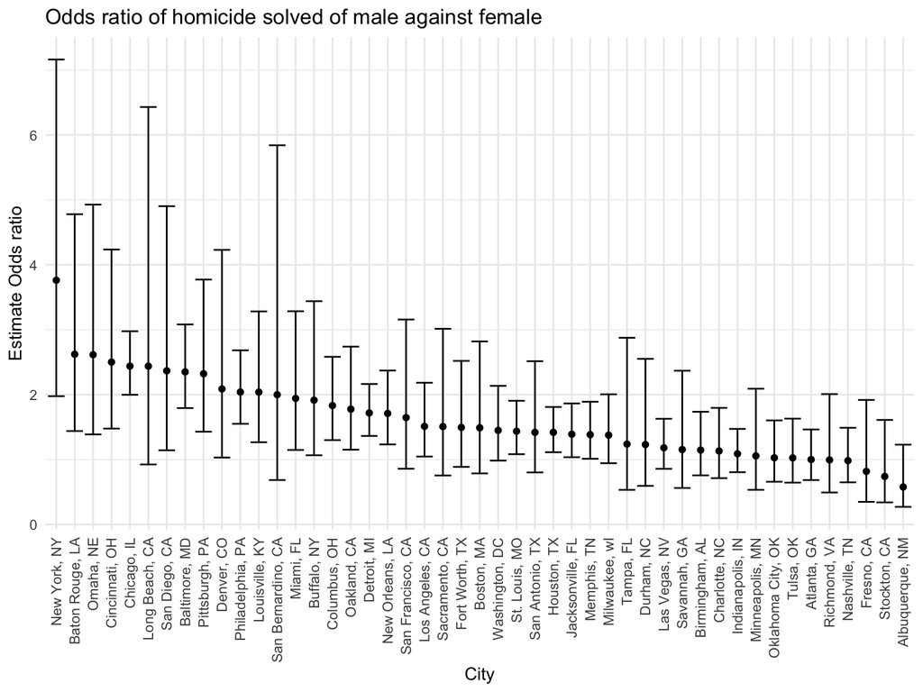

```r
result_df %>%
  ggplot(aes(x = reorder(city_state,-estimate_OR), y = estimate_OR)) +
  geom_point() +
  geom_errorbar(aes(ymin = conf.low, ymax = conf.high)) +
  theme(axis.text.x = element_text(angle = 90, vjust = 0.5, hjust=1)) +
  labs(
    title = "Odds ratio of homicide solved of male against female",
    x = "City",
    y = "Estimate Odds ratio")
```

# Problem 3

## Data cleaning

```r
birth_df = read_csv("./data/birthweight.csv") %>%
  janitor::clean_names() %>%
  mutate_at(c('babysex', 'frace', 'malform', 'mrace'), as.factor) %>%
  mutate(
    smoken = as.factor(ifelse(smoken > 0, 1, 0))
  )

sum(is.na(birth_df))
```

```
## [1] 0
```

`'babysex', 'frace', 'malform', 'mrace'` are changed from double to factors and no missing values are found in the dataframe.

## Cross validation to find parameters for model building

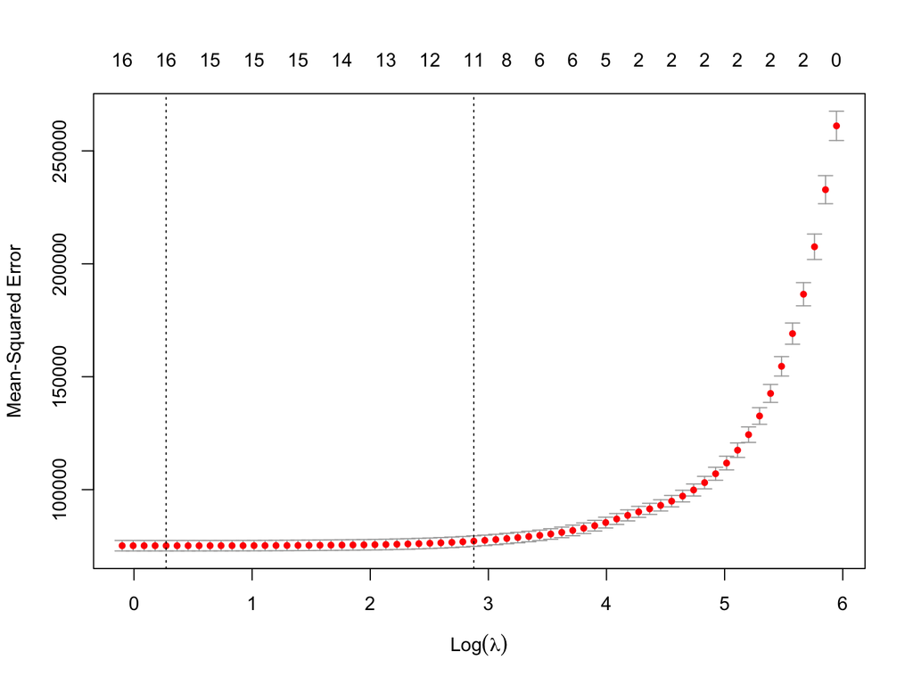

```r
set.seed(1)
# those categorical variables have different indicator for different levels, which needs to be uniform through converting to dummy variables
dummy_df = dummy_cols(
  birth_df,
  select_columns = c('babysex', 'frace', 'malform', 'mrace','smoken'),
  remove_selected_columns = TRUE,
  remove_first_dummy = TRUE
  )
covariates = data.matrix(dummy_df %>% select(-bwt))
birthweight = data.matrix(dummy_df %>% select(bwt))
# 10 folds cv is used
cv_object = cv.glmnet(covariates, birthweight, nfolds = 10)
plot(cv_object)
```

```r
# Find the best lambda with lowest se
best_lambda = cv_object %>% broom::glance() %>% pull(lambda.min)
```

## Build elastic net regression model to find proper parameters

```r
ela_model = glmnet(covariates, birthweight, lambda = best_lambda, alpha = 0.5)
model_coef = coef.glmnet(ela_model) %>% as.matrix() %>% as.data.frame()
coef.glmnet(ela_model)
```

```
## 25 x 1 sparse Matrix of class "dgCMatrix"
##                        s0
## (Intercept) -6057.3324032
## bhead         130.7556667
## blength        75.2963010
## delwt           1.3559487
## fincome         0.2895418
## gaweeks        11.3554558
## menarche       -3.2095198
## mheight         6.5207439
## momage          0.1989054
## parity         94.5922978
## pnumlbw         .
## pnumsga         .
## ppbmi           .
## ppwt            .
## wtgain          2.6989329
## babysex_2      26.7758244
## frace_2         .
## frace_3         .
## frace_4       -42.8633463
## frace_8         .
## malform_1       .
## mrace_2      -123.8566056
## mrace_3       -61.9472548
## mrace_4       -48.2296276
## smoken_1      -55.1050357
```

```r
model_coef[model_coef == 0] = NA
# Extract all of the non-zero variables of elastic net model
selected_var = model_coef %>% na.omit() %>% row.names()
selected_var = selected_var[-1]
# Use the parameters to build a MLR model
final_var = dummy_df %>% select(selected_var) %>% data.matrix()
final_weight = dummy_df %>% pull(bwt)
my_model = lm(final_weight ~ final_var)
# show all of the variables
my_model %>% broom::tidy() %>% transform(term = str_replace(term, "final_var", "")) %>% knitr::kable()
```

| term | estimate | std.error | statistic | p.value |
| --- | --- | --- | --- | --- |
| (Intercept) | -6079.2534420 | 140.9140067 | -43.1415839 | 0.0000000 |
| bhead | 131.0433435 | 3.4589490 | 37.8853072 | 0.0000000 |
| blength | 75.3901017 | 2.0239727 | 37.2485758 | 0.0000000 |
| delwt | 1.3535756 | 0.2363575 | 5.7268150 | 0.0000000 |
| fincome | 0.2937036 | 0.1796001 | 1.6353197 | 0.1020548 |
| gaweeks | 11.4128832 | 1.4685665 | 7.7714447 | 0.0000000 |
| menarche | -3.6808038 | 2.8995885 | -1.2694228 | 0.2043586 |
| mheight | 6.6524549 | 1.8041940 | 3.6872170 | 0.0002295 |
| momage | 0.3253338 | 1.2259459 | 0.2653737 | 0.7907343 |
| parity | 101.2331598 | 40.5763625 | 2.4948801 | 0.0126370 |
| wtgain | 2.7514624 | 0.4339936 | 6.3398686 | 0.0000000 |
| babysex_2 | 28.3364524 | 8.4921680 | 3.3367748 | 0.0008547 |
| frace_4 | -44.9083216 | 42.5286069 | -1.0559556 | 0.2910475 |
| mrace_2 | -125.1941057 | 10.0044391 | -12.5138556 | 0.0000000 |
| mrace_3 | -69.8400301 | 42.8498386 | -1.6298785 | 0.1032000 |
| mrace_4 | -49.6570116 | 43.3325853 | -1.1459508 | 0.2518789 |
| smoken_1 | -56.6361778 | 8.6279474 | -6.5642702 | 0.0000000 |

## Plot residuals against fitted values

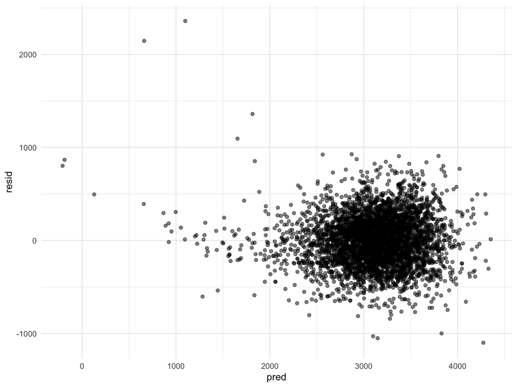

```r
birth_df %>%
  add_residuals(my_model) %>%
  add_predictions(my_model) %>%
  ggplot(aes(x = pred, y = resid)) +
  geom_point(alpha = 0.5)
```

## Compare to other two linear models

```r
# Create dataframe for cross validation
cv_result =
  crossv_mc(dummy_df, 100) %>%
  mutate(
    train = map(train, as_tibble),
    test = map(test, as_tibble)
  )

cv_result =
  cv_result %>%
  mutate(
    my_model = map(train, ~lm(bwt ~ bhead + blength + delwt + fincome +
    gaweeks+ menarche + mheight + momage + parity + wtgain + babysex_2 + frace_4     + mrace_2 + mrace_3 + mrace_4 + smoken_1, data = .x)),
    model_1 = map(train, ~lm(bwt ~ blength + gaweeks, data = .x)),
    model_2 = map(train, ~lm(bwt ~ bhead*blength*babysex_2, data = .x))
  ) %>%
  mutate(
    rmse_my = map2_dbl(my_model, test, ~rmse(model = .x, data = .y)),
    rmse_model_1 = map2_dbl(model_1, test, ~rmse(model = .x, data = .y)),
    rmse_model_2 = map2_dbl(model_2, test, ~rmse(model = .x, data = .y))
  )
```

## Compare rmse as an indicator of model performance

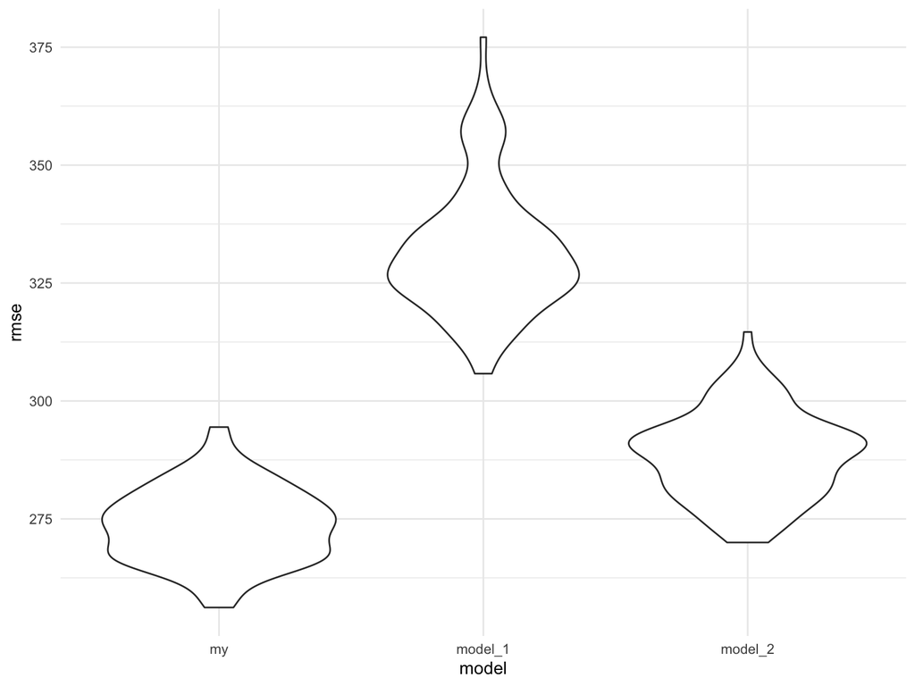

```r
cv_result %>%
  select(starts_with('rmse')) %>%
  pivot_longer(
    everything(),
    names_to = "model",
    values_to = "rmse",
    names_prefix = "rmse_"
  ) %>%
  mutate(model = fct_inorder(model)) %>%
  ggplot(aes(x = model, y = rmse)) + geom_violin()
```

The result shows that the model with variables selected from the elastic net regression has lowest rmse which shows best predictive accurancy compared to two other models.